# GSOC Assignment for Osho Agyeya

```python
#importing libraries
import os
import sys
from datetime import datetime, date, time
import pytz
import numpy as np
import h5py
from scipy.signal import medfilt
from matplotlib import pyplot as plt
import pandas as pd
%matplotlib inline
```

```python
ls
```

```
 Volume in drive E has no label.
 Volume Serial Number is EC94-7793

 Directory of E:\Osho\Personal ventures\GSOC\2019\cern-awake\Evaluation_test\gsoc_eval

09-03-2019  10.42 AM    <DIR>          .
09-03-2019  10.42 AM    <DIR>          ..
09-03-2019  10.39 AM                30 .gitignore
09-03-2019  02.48 AM    <DIR>          .ipynb_checkpoints
09-03-2019  02.22 AM        58,161,744 1541962108935000000_167_838.h5
09-03-2019  10.34 AM           153,091 data.csv
09-03-2019  10.35 AM           565,863 GSOC Assignment for Osho Agyeya.html
09-03-2019  10.42 AM           303,102 GSOC Assignment for Osho Agyeya.ipynb
09-03-2019  10.35 AM             4,185 GSOC_Assignment_for_Osho_Agyeya.py
09-03-2019  10.34 AM           187,900 output_image.png
09-03-2019  02.33 AM             3,017 README.md
               8 File(s)     59,378,932 bytes
               3 Dir(s)  31,447,736,320 bytes free
```

```python
all_files=os.listdir()
h5_file_name=""
for i in all_files:
    if(i.endswith(".h5")):
        h5_file_name=i
print("Name of h5 file is",h5_file_name)
```

```
Name of h5 file is 1541962108935000000_167_838.h5
```

```python
unix_time_seconds=float(h5_file_name[:18])*(10**-9)  #converting seconds to nanoseconds
print("Unix time in seconds is",unix_time_seconds)
```

```
Unix time in seconds is 154196210.8935
```

```python
date_time_object_utc=datetime.utcfromtimestamp(unix_time_seconds)
print("The data time object in UTC is",date_time_object_utc)
```

```
The data time object in UTC is 1974-11-20 16:16:50.893500
```

```python
tz=pytz.timezone('Europe/Zurich')
date_time_object_cern=pytz.utc.localize(date_time_object_utc).astimezone(tz)
print("The data time object for Switzerland/CERN is",date_time_object_cern)
```

```
The data time object for Switzerland/CERN is 1974-11-20 17:16:50.893500+01:00
```

### Task 2:Use the h5py library to open the hdf file. The file is organized as a directory tree with groups and datasets. Write a program which explores all branches of the directory tree and identifies all of the datasets in the file. Your program should create a csv file which records the names of all of the groups and datasets, and includes the size, shape and type of data in each dataset.

```python
filename = h5_file_name
f = h5py.File(filename, 'r')
all_data={}
```

```python
#identifying and printing datasets
def visit_func(name,node):
    if(isinstance(node,h5py.Dataset)):
        print('<HDF5 dataset "/',name,'"',node.shape)
    else:
        print(node)
f.visititems(visit_func)
```

[output not shown]

[output cut: 1959 more lines]

[output not shown]

```python
#identifying and printing datasets
def visit_func(name,node):
    if(isinstance(node,h5py.Dataset)):
        try:
            datatype=node.dtype
        except Exception as e:
            datatype=str(e)
        all_data[name]=['dataset',node.size,node.shape,datatype]
    else:
        all_data[name]=['group','','','']
f.visititems(visit_func)
df = pd.DataFrame.from_dict(all_data,orient='index',
            columns=['TYPE','SIZE','SHAPE','DATA_TYPE'])
print(df.head())
```

```
                                               TYPE SIZE SHAPE DATA_TYPE
AwakeEventData                                group
AwakeEventData/AIRTR01                        group
AwakeEventData/AIRTR01/Acq                    group
AwakeEventData/AIRTR01/Acq/numericPosition  dataset    1  (1,)   float32
AwakeEventData/AIRTR02                        group
```

```python
df.to_csv('data.csv', sep=',')
```

### In the hdf file, there is 2D image data stored as a 1D array in the dataset called "/AwakeEventData/XMPP-STREAK/StreakImage/streakImageData". The datasets "/AwakeEventData/XMPP-STREAK/StreakImage/streakImageHeight" and "/AwakeEventData/XMPP-STREAK/StreakImage/streakImageWidth" store information about the height and width of the image. Use numpy.reshape to convert the 1D array into a 2D image. Then, use scipy.signal.medfilt to filter the image. Finally, use matplotlib to display the image and save it as a png file.

```python
name_image="AwakeEventData/XMPP-STREAK/StreakImage/streakImageData"
name_height="AwakeEventData/XMPP-STREAK/StreakImage/streakImageHeight"
name_width="AwakeEventData/XMPP-STREAK/StreakImage/streakImageWidth"
image_data=None
image_height=None
image_width=None
```

```python
#identifying and printing datasets
def visit_func(name,node):
    global image_data,image_height,image_width
    if(isinstance(node,h5py.Dataset)):
        if(name==name_image):
            image_data=node
        if(name==name_height):
            image_height=node
        if(name==name_width):
            image_width=node
f.visititems(visit_func)
```

```python
print(image_data,image_height,image_width)
```

```
<HDF5 dataset "streakImageData": shape (344064,), type "<i4"> <HDF5 dataset "streakImageHeight": shape (1,), type "<i8"> <HDF5 dataset "streakImageWidth": shape (1,), type "<i8">
```

```python
image_data=np.array(image_data)
image_height=np.array(image_height)[0]
image_width=np.array(image_width)[0]
image_data,image_height,image_width
```

```
(array([405, 412, 402, ..., 403, 412, 413]), 512, 672)
```

```python
image_data=np.reshape(image_data,(image_height,image_width))
print(image_data,image_data.shape)
```

```
[[405 412 402 ... 410 430 409]
 [415 408 417 ... 397 404 408]
 [436 417 412 ... 415 407 400]
 ...
 [411 412 410 ... 409 411 425]
 [414 406 400 ... 410 399 417]
 [413 411 450 ... 403 412 413]] (512, 672)
```

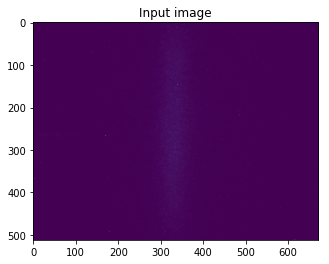

```python
plt.imshow(image_data);
plt.title("Input image");
```

```python
output_data=medfilt(image_data)
print(output_data,output_data.shape)
```

```
[[  0. 405. 407. ... 404. 404.   0.]
 [408. 412. 412. ... 410. 408. 404.]
 [406. 412. 409. ... 407. 406. 404.]
 ...
 [406. 410. 410. ... 411. 414. 411.]
 [411. 411. 411. ... 411. 411. 411.]
 [  0. 406. 406. ... 403. 403.   0.]] (512, 672)
```

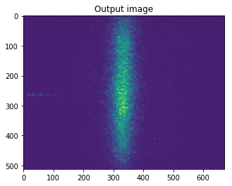

```python
i=plt.imshow(output_data);
plt.title("Output image");
plt.imsave('output_image.png',output_data);
```